# Twitter Sentiment

The purpose of this analysis is to analyze monthly Twitter sentiment. For this analysis, I focused on one sentiment metric: the probability of positive sentiment and deviations from the mean.

```python
%matplotlib inline
%pylab inline
import pandas as pd
import numpy as np
import seaborn as sns
import matplotlib.pyplot as plt
import warnings
import plotly
import plotly.graph_objs as go
warnings.filterwarnings('ignore')
pylab.rcParams['figure.figsize'] = (12, 6)
plotly.offline.init_notebook_mode()
pd.set_option('display.float_format', lambda x: '%.4f' % x)
```

### Load data

Load the historical Twitter data scraped using the tweets_export.py script. Next, load the Twitter username data using the twitter_api.py script.

```python
tweets = pd.read_csv('data/eem_hyg_tweets.csv', encoding='utf-8',
                   usecols=['index','username', 'retweets', 'favorites', 'polarity', 'ticker', 'p_pos', 'p_neg'])
usernames = pd.read_csv('data/twitter_usernames.csv', encoding='utf-8',
                   usecols=['screen_name', 'followers_count'])
```

```python
tweets.head()
```

|  | index | username | retweets | favorites | polarity | ticker | p_pos | p_neg |
| --- | --- | --- | --- | --- | --- | --- | --- | --- |
| 0 | 2015-06-29 16:44:07 | rosnerstocks | 0 | 0 | 0.0000 | eem | 0.6637 | 0.3363 |
| 1 | 2015-06-29 16:35:08 | Jake132013 | 0 | 0 | 0.0000 | eem | 0.6315 | 0.3685 |
| 2 | 2015-06-29 16:30:44 | ETFtrends | 0 | 0 | 0.0000 | eem | 0.7585 | 0.2415 |
| 3 | 2015-06-29 16:18:49 | nicohof1 | 0 | 0 | 0.0000 | eem | 0.6768 | 0.3232 |
| 4 | 2015-06-29 15:43:13 | rosnerstocks | 0 | 0 | 0.0000 | eem | 0.7626 | 0.2374 |

```python
usernames.head()
```

|  | followers_count | screen_name |
| --- | --- | --- |
| 0 | 1477.0000 | rosnerstocks |
| 1 | 941.0000 | Jake132013 |
| 2 | 22857.0000 | ETFtrends |
| 3 | 825.0000 | nicohof1 |
| 4 | 1006.0000 | VRodrigoFP |

### Combine both datasets

Combine the historical tweets and usernames data into one dataframe and drop unused columns.

```python
data = tweets.merge(usernames, how='outer', left_on='username', right_on='screen_name')
data['date'] = pd.to_datetime(data['index'])
data.drop(['screen_name', 'username', 'index'], axis=1, inplace=True)
data.fillna(0, inplace=True)
data.set_index('date', inplace=True)
data.index = data.index.normalize()
data.head()
```

| date | retweets | favorites | polarity | ticker | p_pos | p_neg | followers_count |
| --- | --- | --- | --- | --- | --- | --- | --- |
| 2015-06-29 | 0.0000 | 0.0000 | 0.0000 | eem | 0.6637 | 0.3363 | 1477.0000 |
| 2015-06-29 | 0.0000 | 0.0000 | 0.0000 | eem | 0.7626 | 0.2374 | 1477.0000 |
| 2015-06-29 | 0.0000 | 0.0000 | 0.0000 | eem | 0.7013 | 0.2987 | 1477.0000 |
| 2015-06-29 | 0.0000 | 0.0000 | 0.0000 | eem | 0.7451 | 0.2549 | 1477.0000 |
| 2015-06-29 | 0.0000 | 0.0000 | 0.0000 | eem | 0.7558 | 0.2442 | 1477.0000 |

### Get the number of monthly tweets

```python
total = pd.DataFrame(data.groupby([pd.TimeGrouper('M', closed='right'), 'ticker'])['ticker'].count())
total.columns = ['monthly_tweet_count']
total_eem = total[total.index.get_level_values(1) == 'eem']
total_eem = total_eem.reset_index(level=1).resample('D', how='last', fill_method='bfill').set_index('ticker', append=True)
total_hyg = total[total.index.get_level_values(1) == 'hyg']
total_hyg = total_hyg.reset_index(level=1).resample('D', how='last', fill_method='bfill').set_index('ticker', append=True)
total = total_eem.append(total_hyg).sort_index()
total.head()
```

| date | ticker | monthly_tweet_count |
| --- | --- | --- |
| 2014-12-31 | eem | 2.0000 |
|  | hyg | 1.0000 |
| 2015-01-01 | eem | 1121.0000 |
|  | hyg | 874.0000 |
| 2015-01-02 | eem | 1121.0000 |

### Create new features

Next, I calculated the weight of each tweet based on the percentage of total monthly tweets. The weight was applied to the probability that a tweet is positive (p_pos_w).

```python
df = data.set_index('ticker', append=True).join(total)
df['tweet_count'] = 1
df['weight'] = df.tweet_count / df.monthly_tweet_count
df['p_pos_w'] = df.weight*df.p_pos
df['p_neg_w'] = df.weight*df.p_neg
df['polarity_w'] = df.weight*df.polarity
df = df.drop(['p_pos', 'p_neg', 'polarity'], axis=1)
df.loc['2015-01-01']
```

| date | ticker | retweets | favorites | followers_count | monthly_tweet_count | tweet_count | weight | p_pos_w | p_neg_w | polarity_w |
| --- | --- | --- | --- | --- | --- | --- | --- | --- | --- | --- |
| 2015-01-01 | eem | 0.0000 | 1.0000 | 1477.0000 | 1121.0000 | 1 | 0.0009 | 0.0008 | 0.0001 | 0.0000 |
|  | eem | 0.0000 | 0.0000 | 297.0000 | 1121.0000 | 1 | 0.0009 | 0.0005 | 0.0003 | 0.0000 |
|  | eem | 0.0000 | 0.0000 | 297.0000 | 1121.0000 | 1 | 0.0009 | 0.0008 | 0.0001 | 0.0000 |
|  | eem | 0.0000 | 0.0000 | 2109.0000 | 1121.0000 | 1 | 0.0009 | 0.0007 | 0.0002 | 0.0000 |
|  | eem | 0.0000 | 0.0000 | 2388.0000 | 1121.0000 | 1 | 0.0009 | 0.0003 | 0.0006 | 0.0000 |
|  | eem | 0.0000 | 2.0000 | 13311.0000 | 1121.0000 | 1 | 0.0009 | 0.0004 | 0.0004 | 0.0000 |
|  | eem | 0.0000 | 0.0000 | 429.0000 | 1121.0000 | 1 | 0.0009 | 0.0008 | 0.0001 | 0.0000 |
|  | eem | 0.0000 | 0.0000 | 4145.0000 | 1121.0000 | 1 | 0.0009 | 0.0007 | 0.0002 | 0.0009 |
|  | eem | 0.0000 | 0.0000 | 1446.0000 | 1121.0000 | 1 | 0.0009 | 0.0001 | 0.0008 | 0.0000 |
|  | eem | 0.0000 | 0.0000 | 693.0000 | 1121.0000 | 1 | 0.0009 | 0.0004 | 0.0005 | 0.0000 |
|  | eem | 0.0000 | 0.0000 | 808.0000 | 1121.0000 | 1 | 0.0009 | 0.0007 | 0.0002 | 0.0000 |
|  | eem | 0.0000 | 0.0000 | 808.0000 | 1121.0000 | 1 | 0.0009 | 0.0007 | 0.0002 | 0.0000 |
|  | eem | 0.0000 | 1.0000 | 5563.0000 | 1121.0000 | 1 | 0.0009 | 0.0005 | 0.0004 | 0.0000 |
|  | eem | 0.0000 | 0.0000 | 646.0000 | 1121.0000 | 1 | 0.0009 | 0.0009 | 0.0000 | -0.0007 |
|  | eem | 0.0000 | 0.0000 | 549.0000 | 1121.0000 | 1 | 0.0009 | 0.0006 | 0.0003 | 0.0000 |
|  | hyg | 0.0000 | 0.0000 | 1477.0000 | 874.0000 | 1 | 0.0011 | 0.0011 | 0.0000 | 0.0000 |
|  | hyg | 0.0000 | 1.0000 | 10561.0000 | 874.0000 | 1 | 0.0011 | 0.0007 | 0.0004 | 0.0000 |
|  | hyg | 1.0000 | 1.0000 | 10561.0000 | 874.0000 | 1 | 0.0011 | 0.0007 | 0.0005 | -0.0003 |
|  | hyg | 0.0000 | 0.0000 | 429.0000 | 874.0000 | 1 | 0.0011 | 0.0011 | 0.0001 | 0.0000 |
|  | hyg | 0.0000 | 0.0000 | 200.0000 | 874.0000 | 1 | 0.0011 | 0.0007 | 0.0005 | 0.0000 |
|  | hyg | 0.0000 | 0.0000 | 2200.0000 | 874.0000 | 1 | 0.0011 | 0.0006 | 0.0006 | 0.0000 |

### Group into monthly data

Finally, the data was grouped into monthly frequency and aggregated. Unnecessary columns were also dropped to produce the final dataset.

```python
f = {'tweet_count':['sum'], 'retweets':['sum'], 'favorites':['sum'], 'polarity_w':['sum'],
     'p_pos_w':['sum'], 'p_neg_w':['sum'], 'followers_count':['sum'], 'monthly_tweet_count':['sum'],
     'weight':['sum']}

groups = df.reset_index(level=1).groupby([pd.TimeGrouper('M'),'ticker'])
df = groups.agg(f)
df.drop(['1970-01-31'], inplace=True)
df.drop(['weight', 'monthly_tweet_count'], axis=1, inplace=True)
df.columns = df.columns.get_level_values(0)
df.head()
```

| date | ticker | retweets | p_neg_w | favorites | tweet_count | p_pos_w | followers_count | polarity_w |
| --- | --- | --- | --- | --- | --- | --- | --- | --- |
| 2014-12-31 | eem | 0.0000 | 0.1843 | 1.0000 | 2 | 0.8157 | 13100.0000 | 0.0000 |
|  | hyg | 0.0000 | 0.4533 | 0.0000 | 1 | 0.5467 | 321.0000 | -0.7000 |
| 2015-01-31 | eem | 328.0000 | 0.2376 | 435.0000 | 1121 | 0.7624 | 5478214.0000 | 0.0402 |
|  | hyg | 240.0000 | 0.2296 | 362.0000 | 874 | 0.7704 | 4343461.0000 | 0.0311 |
| 2015-02-28 | eem | 170.0000 | 0.2992 | 244.0000 | 943 | 0.7008 | 3545623.0000 | 0.0336 |

### Separate the dataset into EEM and HYG

For ease of plotting, the dataset was split into two dataframes, one for each ticker.

```python
eem_df = df.reset_index(level=1)[df.index.get_level_values(1) == 'eem']
hyg_df = df.reset_index(level=1)[df.index.get_level_values(1) == 'hyg']
```

```python
eem_df.head()
```

| date | ticker | retweets | p_neg_w | favorites | tweet_count | p_pos_w | followers_count | polarity_w |
| --- | --- | --- | --- | --- | --- | --- | --- | --- |
| 2014-12-31 | eem | 0.0000 | 0.1843 | 1.0000 | 2 | 0.8157 | 13100.0000 | 0.0000 |
| 2015-01-31 | eem | 328.0000 | 0.2376 | 435.0000 | 1121 | 0.7624 | 5478214.0000 | 0.0402 |
| 2015-02-28 | eem | 170.0000 | 0.2992 | 244.0000 | 943 | 0.7008 | 3545623.0000 | 0.0336 |
| 2015-03-31 | eem | 273.0000 | 0.3187 | 341.0000 | 1005 | 0.6813 | 7380253.0000 | 0.0309 |
| 2015-04-30 | eem | 472.0000 | 0.2815 | 619.0000 | 1182 | 0.7185 | 10090891.0000 | 0.0507 |

```python
hyg_df.head()
```

| date | ticker | retweets | p_neg_w | favorites | tweet_count | p_pos_w | followers_count | polarity_w |
| --- | --- | --- | --- | --- | --- | --- | --- | --- |
| 2014-12-31 | hyg | 0.0000 | 0.4533 | 0.0000 | 1 | 0.5467 | 321.0000 | -0.7000 |
| 2015-01-31 | hyg | 240.0000 | 0.2296 | 362.0000 | 874 | 0.7704 | 4343461.0000 | 0.0311 |
| 2015-02-28 | hyg | 190.0000 | 0.2847 | 237.0000 | 901 | 0.7153 | 3561552.0000 | 0.0571 |
| 2015-03-31 | hyg | 208.0000 | 0.2810 | 269.0000 | 860 | 0.7190 | 3926348.0000 | 0.0439 |
| 2015-04-30 | hyg | 196.0000 | 0.2435 | 173.0000 | 682 | 0.7565 | 2314834.0000 | 0.0554 |

### Plot histograms of the sentiment distribution for each ticker

From the histrograms, it looks like HYG has more of a positive sentiment bias than EEM.

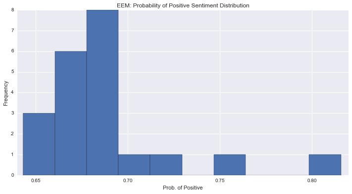

```python
plt.title('EEM: Probability of Positive Sentiment Distribution')
plt.xlabel('Prob. of Positive')
plt.ylabel('Frequency')
eem_df['p_pos_w'].hist()
```

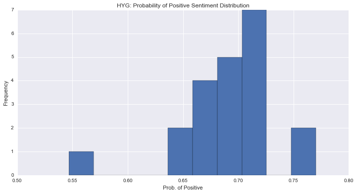

```python
plt.title('HYG: Probability of Positive Sentiment Distribution')
plt.xlabel('Prob. of Positive')
plt.ylabel('Frequency')
hyg_df['p_pos_w'].hist()
```

### Plot a bubble chart

Bubble charts are like a traditional scatter plot. The main difference is the added dimension which is the size of each marker. In this case, the x-axis is time, y-axis is sentiment value, and s-axis is the volume of tweets that month. The assumption here is that months with more tweets signal more conviction. I've also added lines for mean sentiment values for comparison.

```python
eem_mean = np.full((1, len(eem_df.index)), eem_df['p_pos_w'].mean())
hyg_mean = np.full((1, len(hyg_df.index)), hyg_df['p_pos_w'].mean())
```

```python
trace0 = go.Scatter(x=eem_df.index,
                    y=eem_df['p_pos_w'].values,
                    mode='markers',
                    name='EEM Sentiment',
                    marker=dict(size=eem_df['tweet_count'].values,
                                sizemode='area',
                                color='blue')
                   )

trace1 = go.Scatter(x=eem_df.index,
                    y=eem_mean[0],
                    name='EEM Mean Sentiment',
                    line=dict(color='black',
                                dash='dash')
                   )

trace2 = go.Scatter(x=hyg_df.index,
                    y=hyg_df['p_pos_w'].values,
                    mode='markers',
                    name='HYG Sentiment',
                    marker=dict(size=hyg_df['tweet_count'].values,
                                sizemode='area')
                   )

trace3 = go.Scatter(x=hyg_df.index,
                    y=hyg_mean[0],
                    name='HYG Mean Sentiment',
                    line=dict(color='grey',
                               dash='dash')
                   )

layout = go.Layout(title='Twitter Sentiment of EEM & HYG',
                   xaxis=dict(title='Time'),
                   yaxis=dict(title='Sentiment'))

# plot in notebook
plotly.offline.iplot({
    "data": [trace0, trace1, trace2, trace3],
    "layout": layout
}, show_link=False)
```

[interactive chart not shown]

### Next Steps

- Explore other features such as the followers_count field as a proxy for the "reach" that each tweet has.
- Scrub Twitter data thoroughly to get rid of nonsensical tweets.
- Create and / or refine sentiment classification algorithm.
- Explore other features of the Twitter dataset such as volume of tweets, follower count, retweets, and favorites.
- Create a forecast model using live Twitter feeds.